# ExtraaLearn Project

## Context

The EdTech industry has been surging in the past decade immensely, and according to a forecast, the Online Education market would be worth $286.62bn by 2023 with a compound annual growth rate (CAGR) of 10.26% from 2018 to 2023. The modern era of online education has enforced a lot in its growth and expansion beyond any limit. Due to having many dominant features like ease of information sharing, personalized learning experience, transparency of assessment, etc, it is now preferable to traditional education.

In the present scenario due to the Covid-19, the online education sector has witnessed rapid growth and is attracting a lot of new customers. Due to this rapid growth, many new companies have emerged in this industry. With the availability and ease of use of digital marketing resources, companies can reach out to a wider audience with their offerings. The customers who show interest in these offerings are termed as leads. There are various sources of obtaining leads for Edtech companies, like

- The customer interacts with the marketing front on social media or other online platforms.
- The customer browses the website/app and downloads the brochure
- The customer connects through emails for more information.

The company then nurtures these leads and tries to convert them to paid customers. For this, the representative from the organization connects with the lead on call or through email to share further details.

## Objective

ExtraaLearn is an initial stage startup that offers programs on cutting-edge technologies to students and professionals to help them upskill/reskill. With a large number of leads being generated on a regular basis, one of the issues faced by ExtraaLearn is to identify which of the leads are more likely to convert so that they can allocate resources accordingly. You, as a data scientist at ExtraaLearn, have been provided the leads data to:

- Analyze and build an ML model to help identify which leads are more likely to convert to paid customers,
- Find the factors driving the lead conversion process
- Create a profile of the leads which are likely to convert

## Data Description

The data contains the different attributes of leads and their interaction details with ExtraaLearn. The detailed data dictionary is given below.

**Data Dictionary**

- ID: ID of the lead
- age: Age of the lead
- current_occupation: Current occupation of the lead. Values include 'Professional','Unemployed',and 'Student'
- first_interaction: How did the lead first interacted with ExtraaLearn. Values include 'Website', 'Mobile App'
- profile_completed: What percentage of profile has been filled by the lead on the website/mobile app. Values include Low - (0-50%), Medium - (50-75%), High (75-100%)
- website_visits: How many times has a lead visited the website
- time_spent_on_website: Total time spent on the website
- page_views_per_visit: Average number of pages on the website viewed during the visits.
- last_activity: Last interaction between the lead and ExtraaLearn.
  - Email Activity: Seeking for details about program through email, Representative shared information with lead like brochure of program , etc
  - Phone Activity: Had a Phone Conversation with representative, Had conversation over SMS with representative, etc
  - Website Activity: Interacted on live chat with representative, Updated profile on website, etc
- print_media_type1: Flag indicating whether the lead had seen the ad of ExtraaLearn in the Newspaper.
- print_media_type2: Flag indicating whether the lead had seen the ad of ExtraaLearn in the Magazine.
- digital_media: Flag indicating whether the lead had seen the ad of ExtraaLearn on the digital platforms.
- educational_channels: Flag indicating whether the lead had heard about ExtraaLearn in the education channels like online forums, discussion threads, educational websites, etc.
- referral: Flag indicating whether the lead had heard about ExtraaLearn through reference.
- status: Flag indicating whether the lead was converted to a paid customer or not.

## Importing necessary libraries and data

```python
import pandas as pd
import numpy as np

# Libaries to help with data visualization
import matplotlib.pyplot as plt
import seaborn as sns
sns.set()

# Importing the Machine Learning models we require from Scikit-Learn
from sklearn.linear_model import LogisticRegression
from sklearn.svm import SVC
from sklearn.tree import DecisionTreeClassifier
from sklearn import tree
from sklearn.ensemble import RandomForestClassifier

# Importing the other functions we may require from Scikit-Learn
from sklearn.model_selection import train_test_split, GridSearchCV
from sklearn.preprocessing import MinMaxScaler, LabelEncoder, OneHotEncoder
from sklearn.impute import SimpleImputer

# To get diferent metric scores
from sklearn.metrics import confusion_matrix,classification_report,roc_auc_score,precision_recall_curve,roc_curve,make_scorer

# Code to ignore warnings from function usage
import warnings;
import numpy as np
warnings.filterwarnings('ignore')
```

## Data Overview

- Observations
- Sanity checks

```python
data = pd.read_excel('/Users/faraazzuberi/Downloads/ExtraaLearn.xlsx', sheet_name="ExtraaLearn", engine='openpyxl')

data.head()
```

|  | ID | age | current_occupation | first_interaction | profile_completed | website_visits | time_spent_on_website | page_views_per_visit | last_activity | print_media_type1 | print_media_type2 | digital_media | educational_channels | referral | status |
| --- | --- | --- | --- | --- | --- | --- | --- | --- | --- | --- | --- | --- | --- | --- | --- |
| 0 | EXT001 | 57 | Unemployed | Website | High | 7 | 1639 | 1.861 | Website Activity | Yes | No | Yes | No | No | 1 |
| 1 | EXT002 | 56 | Professional | Mobile App | Medium | 2 | 83 | 0.320 | Website Activity | No | No | No | Yes | No | 0 |
| 2 | EXT003 | 52 | Professional | Website | Medium | 3 | 330 | 0.074 | Website Activity | No | No | Yes | No | No | 0 |
| 3 | EXT004 | 53 | Unemployed | Website | High | 4 | 464 | 2.057 | Website Activity | No | No | No | No | No | 1 |
| 4 | EXT005 | 23 | Student | Website | High | 4 | 600 | 16.914 | Email Activity | No | No | No | No | No | 0 |

```python
data.tail()
```

|  | ID | age | current_occupation | first_interaction | profile_completed | website_visits | time_spent_on_website | page_views_per_visit | last_activity | print_media_type1 | print_media_type2 | digital_media | educational_channels | referral | status |
| --- | --- | --- | --- | --- | --- | --- | --- | --- | --- | --- | --- | --- | --- | --- | --- |
| 4607 | EXT4608 | 35 | Unemployed | Mobile App | Medium | 15 | 360 | 2.170 | Phone Activity | No | No | No | Yes | No | 0 |
| 4608 | EXT4609 | 55 | Professional | Mobile App | Medium | 8 | 2327 | 5.393 | Email Activity | No | No | No | No | No | 0 |
| 4609 | EXT4610 | 58 | Professional | Website | High | 2 | 212 | 2.692 | Email Activity | No | No | No | No | No | 1 |
| 4610 | EXT4611 | 57 | Professional | Mobile App | Medium | 1 | 154 | 3.879 | Website Activity | Yes | No | No | No | No | 0 |
| 4611 | EXT4612 | 55 | Professional | Website | Medium | 4 | 2290 | 2.075 | Phone Activity | No | No | No | No | No | 0 |

# Understanding the shape of the dataset

```python
data.shape
```

```
(4612, 15)
```

The dataset has 4612 rows and 15 columns

## Data Preprocessing

- Missing value treatment (if needed)
- Feature engineering (if needed)
- Outlier detection and treatment (if needed)
- Preparing data for modeling
- Any other preprocessing steps (if needed)

# Check the data types of the columns for the dataset

```python
data.info()
```

```
<class 'pandas.core.frame.DataFrame'>
RangeIndex: 4612 entries, 0 to 4611
Data columns (total 15 columns):
 #   Column                 Non-Null Count  Dtype
---  ------                 --------------  -----
 0   ID                     4612 non-null   object
 1   age                    4612 non-null   int64
 2   current_occupation     4612 non-null   object
 3   first_interaction      4612 non-null   object
 4   profile_completed      4612 non-null   object
 5   website_visits         4612 non-null   int64
 6   time_spent_on_website  4612 non-null   int64
 7   page_views_per_visit   4612 non-null   float64
 8   last_activity          4612 non-null   object
 9   print_media_type1      4612 non-null   object
 10  print_media_type2      4612 non-null   object
 11  digital_media          4612 non-null   object
 12  educational_channels   4612 non-null   object
 13  referral               4612 non-null   object
 14  status                 4612 non-null   int64
dtypes: float64(1), int64(4), object(10)
memory usage: 540.6+ KB
```

# Check the % of missing values in each column

```python
pd.DataFrame(data={'% of Missing Values':round(data.isna().sum()/data.isna().count()*100,2)}).sort_values(by='% of Missing Values',ascending=False)
```

|  | % of Missing Values |
| --- | --- |
| ID | 0.0 |
| age | 0.0 |
| current_occupation | 0.0 |
| first_interaction | 0.0 |
| profile_completed | 0.0 |
| website_visits | 0.0 |
| time_spent_on_website | 0.0 |
| page_views_per_visit | 0.0 |
| last_activity | 0.0 |
| print_media_type1 | 0.0 |
| print_media_type2 | 0.0 |
| digital_media | 0.0 |
| educational_channels | 0.0 |
| referral | 0.0 |
| status | 0.0 |

# Check the number of unique values in each column

```python
data.nunique()
```

```
ID                       4612
age                        46
current_occupation          3
first_interaction           2
profile_completed           3
website_visits             27
time_spent_on_website    1623
page_views_per_visit     2414
last_activity               3
print_media_type1           2
print_media_type2           2
digital_media               2
educational_channels        2
referral                    2
status                      2
dtype: int64
```

## Exploratory Data Analysis (EDA)

- EDA is an important part of any project involving data.
- It is important to investigate and understand the data better before building a model with it.
- A few questions have been mentioned below which will help you approach the analysis in the right manner and generate insights from the data.
- A thorough analysis of the data, in addition to the questions mentioned below, should be done.

**Questions**

1. Leads will have different expectations from the outcome of the course and the current occupation may play a key role in getting them to participate in the program. Find out how current occupation affects lead status.
2. The company's first impression on the customer must have an impact. Do the first channels of interaction have an impact on the lead status?
3. The company uses multiple modes to interact with prospects. Which way of interaction works best?
4. The company gets leads from various channels such as print media, digital media, referrals, etc. Which of these channels have the highest lead conversion rate?
5. People browsing the website or mobile application are generally required to create a profile by sharing their personal data before they can access additional information.Does having more details about a prospect increase the chances of conversion?

## EDA

- It is a good idea to explore the data once again after manipulating it.

# Question 1

Leads will have different expectations from the outcome of the course and the current occupation may play a key role in getting them to participate in the program. Find out how current occupation affects lead status.

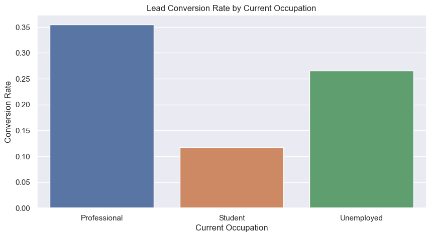

```
Statistical Summary for Current Occupation and Lead Status:
                      count      mean       std  min  25%  50%  75%  max
current_occupation
Professional        2616.0  0.355122  0.478642  0.0  0.0  0.0  1.0  1.0
Student              555.0  0.117117  0.321850  0.0  0.0  0.0  0.0  1.0
Unemployed          1441.0  0.265788  0.441905  0.0  0.0  0.0  1.0  1.0
```

```python
# Analyzing how current occupation affects lead status
occupation_status = data.groupby('current_occupation')['status'].mean().reset_index()

# Plotting
plt.figure(figsize=(10, 5))
sns.barplot(x='current_occupation', y='status', data=occupation_status)
plt.title('Lead Conversion Rate by Current Occupation')
plt.xlabel('Current Occupation')
plt.ylabel('Conversion Rate')
plt.show()

# Detailed statistical summary
occupation_summary = data.groupby('current_occupation')['status'].describe()
print("Statistical Summary for Current Occupation and Lead Status:\n", occupation_summary)
```

# Question 2

The company's first impression on the customer must have an impact. Do the first channels of interaction have an impact on the lead status?

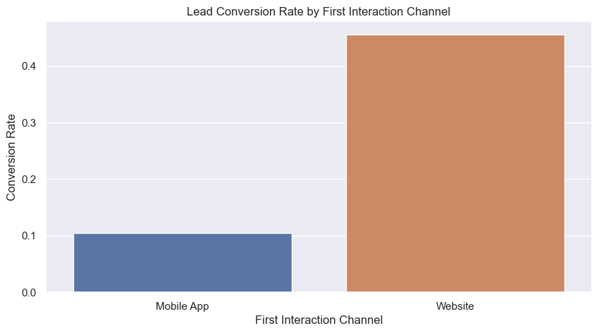

```
Statistical Summary for First Interaction Channel and Lead Status:
                     count      mean       std  min  25%  50%  75%  max
first_interaction
Mobile App         2070.0  0.105314  0.307032  0.0  0.0  0.0  0.0  1.0
Website            2542.0  0.455940  0.498153  0.0  0.0  0.0  1.0  1.0
```

```python
# Analyzing the impact of first interaction channels on lead status
interaction_status = data.groupby('first_interaction')['status'].mean().reset_index()

# Plotting
plt.figure(figsize=(10, 5))
sns.barplot(x='first_interaction', y='status', data=interaction_status)
plt.title('Lead Conversion Rate by First Interaction Channel')
plt.xlabel('First Interaction Channel')
plt.ylabel('Conversion Rate')
plt.show()

# Detailed statistical summary
interaction_summary = data.groupby('first_interaction')['status'].describe()
print("Statistical Summary for First Interaction Channel and Lead Status:\n", interaction_summary)
```

# Question 3

The company uses multiple modes to interact with prospects. Which way of interaction works best?

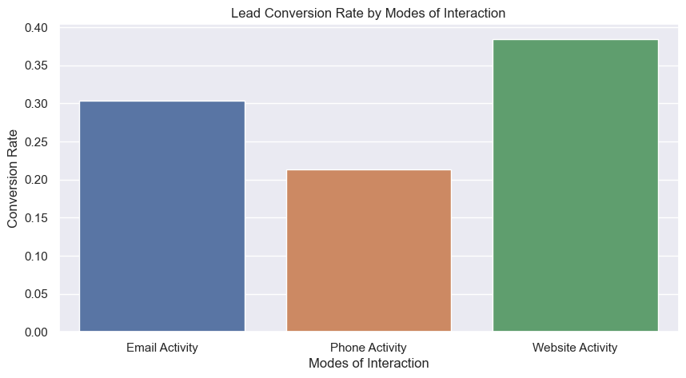

```
Statistical Summary for Modes of Interaction and Lead Status:
                    count      mean       std  min  25%  50%  75%  max
last_activity
Email Activity    2278.0  0.303336  0.459800  0.0  0.0  0.0  1.0  1.0
Phone Activity    1234.0  0.213128  0.409683  0.0  0.0  0.0  0.0  1.0
Website Activity  1100.0  0.384545  0.486709  0.0  0.0  0.0  1.0  1.0
```

```python
# Analyzing which modes of interaction work best
modes_of_interaction = data.groupby('last_activity')['status'].mean().reset_index()

# Plotting
plt.figure(figsize=(10, 5))
sns.barplot(x='last_activity', y='status', data=modes_of_interaction)
plt.title('Lead Conversion Rate by Modes of Interaction')
plt.xlabel('Modes of Interaction')
plt.ylabel('Conversion Rate')
plt.show()

# Detailed statistical summary
interaction_modes_summary = data.groupby('last_activity')['status'].describe()
print("Statistical Summary for Modes of Interaction and Lead Status:\n", interaction_modes_summary)
```

# Question 4

The company gets leads from various channels such as print media, digital media, referrals, etc. Which of these channels have the highest lead conversion rate?

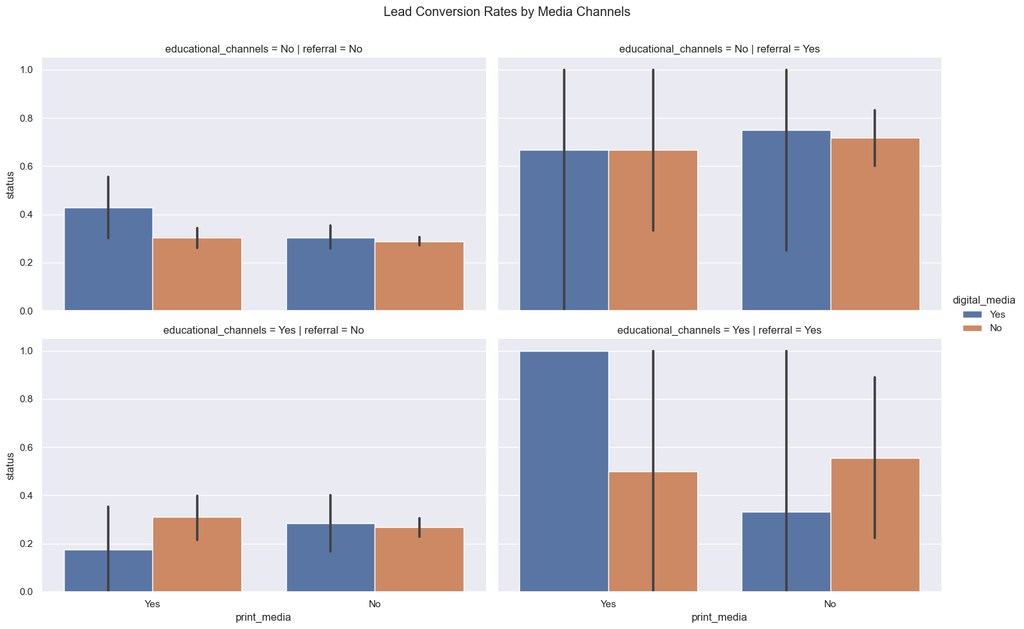

```
Statistical Summary for Media Channels and Lead Conversion:
                                                           count      mean  \
print_media digital_media educational_channels referral
No          No            No                   No        2883.0  0.288241
                                               Yes         60.0  0.716667
                          Yes                  No         518.0  0.268340
                                               Yes          9.0  0.555556
            Yes           No                   No         376.0  0.303191
                                               Yes          4.0  0.750000
                          Yes                  No          60.0  0.283333
                                               Yes          3.0  0.333333
Yes         No            No                   No         509.0  0.302554
                                               Yes          9.0  0.666667
                          Yes                  No          93.0  0.311828
                                               Yes          4.0  0.500000
            Yes           No                   No          63.0  0.428571
                                               Yes          3.0  0.666667
                          Yes                  No          17.0  0.176471
                                               Yes          1.0  1.000000

                                                              std  min   25%  \
print_media digital_media educational_channels referral
No          No            No                   No        0.453023  0.0  0.00
                                               Yes       0.454420  0.0  0.00
                          Yes                  No        0.443524  0.0  0.00
                                               Yes       0.527046  0.0  0.00
            Yes           No                   No        0.460250  0.0  0.00
                                               Yes       0.500000  0.0  0.75
                          Yes                  No        0.454420  0.0  0.00
                                               Yes       0.577350  0.0  0.00
Yes         No            No                   No        0.459816  0.0  0.00
                                               Yes       0.500000  0.0  0.00
                          Yes                  No        0.465751  0.0  0.00
                                               Yes       0.577350  0.0  0.00
            Yes           No                   No        0.498847  0.0  0.00
                                               Yes       0.577350  0.0  0.50
                          Yes                  No        0.392953  0.0  0.00
                                               Yes            NaN  1.0  1.00

                                                         50%  75%  max
print_media digital_media educational_channels referral
No          No            No                   No        0.0  1.0  1.0
                                               Yes       1.0  1.0  1.0
                          Yes                  No        0.0  1.0  1.0
                                               Yes       1.0  1.0  1.0
            Yes           No                   No        0.0  1.0  1.0
                                               Yes       1.0  1.0  1.0
                          Yes                  No        0.0  1.0  1.0
                                               Yes       0.0  0.5  1.0
Yes         No            No                   No        0.0  1.0  1.0
                                               Yes       1.0  1.0  1.0
                          Yes                  No        0.0  1.0  1.0
                                               Yes       0.5  1.0  1.0
            Yes           No                   No        0.0  1.0  1.0
                                               Yes       1.0  1.0  1.0
                          Yes                  No        0.0  0.0  1.0
                                               Yes       1.0  1.0  1.0
```

```python
# Analyzing lead conversion rates for different media channels
media_channels = data.groupby(['print_media', 'digital_media', 'educational_channels', 'referral'])['status'].mean().reset_index()

# Plotting
plt.figure(figsize=(15, 8))
sns.catplot(x='print_media', y='status', hue='digital_media', col='referral', row='educational_channels', data=data, kind='bar', height=5, aspect=1.5)
plt.subplots_adjust(top=0.9)
plt.suptitle('Lead Conversion Rates by Media Channels')
plt.show()

# Detailed statistical summary
media_channels_summary = data.groupby(['print_media', 'digital_media', 'educational_channels', 'referral'])['status'].describe()
print("Statistical Summary for Media Channels and Lead Conversion:\n", media_channels_summary)
```

# Question 5

People browsing the website or mobile application are generally required to create a profile by sharing their personal data before they can access additional information.Does having more details about a prospect increase the chances of conversion?

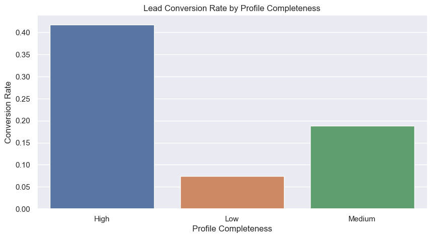

```
Statistical Summary for Profile Completeness and Lead Status:
                     count      mean       std  min  25%  50%  75%  max
profile_completed
High               2264.0  0.417845  0.493313  0.0  0.0  0.0  1.0  1.0
Low                 107.0  0.074766  0.264252  0.0  0.0  0.0  0.0  1.0
Medium             2241.0  0.188755  0.391401  0.0  0.0  0.0  0.0  1.0
```

```python
# Evaluating if having more details about a prospect increases the chances of conversion
profile_completeness = data.groupby('profile_completed')['status'].mean().reset_index()

# Plotting
plt.figure(figsize=(10, 5))
sns.barplot(x='profile_completed', y='status', data=profile_completeness)
plt.title('Lead Conversion Rate by Profile Completeness')
plt.xlabel('Profile Completeness')
plt.ylabel('Conversion Rate')
plt.show()

# Detailed statistical summary
profile_completeness_summary = data.groupby('profile_completed')['status'].describe()
print("Statistical Summary for Profile Completeness and Lead Status:\n", profile_completeness_summary)
```

## Building a Decision Tree model

# Data Preprocessing

```python
# Load the dataset
data = pd.read_excel('/Users/faraazzuberi/Downloads/ExtraaLearn.xlsx', sheet_name='ExtraaLearn', engine='openpyxl')

# Checking for missing values
missing_values = data.isnull().sum()
print("Missing values in each column:\n", missing_values)

# Combining print media columns for analysis
data['print_media'] = data[['print_media_type1', 'print_media_type2']].apply(lambda x: 'Yes' if 'Yes' in x.values else 'No', axis=1)

# Encoding categorical variables
label_encoders = {}
categorical_columns = ['current_occupation', 'first_interaction', 'last_activity', 'print_media', 'digital_media', 'educational_channels', 'referral', 'profile_completed']

for column in categorical_columns:
    le = LabelEncoder()
    data[column] = le.fit_transform(data[column])
    label_encoders[column] = le
```

```
Missing values in each column:
 ID                       0
age                      0
current_occupation       0
first_interaction        0
profile_completed        0
website_visits           0
time_spent_on_website    0
page_views_per_visit     0
last_activity            0
print_media_type1        0
print_media_type2        0
digital_media            0
educational_channels     0
referral                 0
status                   0
dtype: int64
```

```python
# Selecting features and target variable
features = ['age', 'current_occupation', 'first_interaction', 'website_visits', 'time_spent_on_website', 'page_views_per_visit', 'last_activity', 'print_media', 'digital_media', 'educational_channels', 'referral', 'profile_completed']
X = data[features]
y = data['status']
```

# Splitting the data into training and testing sets

```python
# Splitting the data into training and testing sets
from sklearn.model_selection import train_test_split

X_train, X_test, y_train, y_test = train_test_split(X, y, test_size=0.3, random_state=42)
```

# Training the model

```python
from sklearn.tree import DecisionTreeClassifier

decision_tree = DecisionTreeClassifier(random_state=42)
decision_tree.fit(X_train, y_train)
```

```
DecisionTreeClassifier(random_state=42)
```

# Evaluating the model

```python
# Making predictions
y_pred = decision_tree.predict(X_test)

# Evaluating the model
from sklearn.metrics import confusion_matrix, classification_report, accuracy_score

print("Confusion Matrix:\n", confusion_matrix(y_test, y_pred))
print("\nClassification Report:\n", classification_report(y_test, y_pred))
print("\nAccuracy Score:", accuracy_score(y_test, y_pred))
```

```
Confusion Matrix:
 [[831 146]
 [141 266]]

Classification Report:
               precision    recall  f1-score   support

           0       0.85      0.85      0.85       977
           1       0.65      0.65      0.65       407

    accuracy                           0.79      1384
   macro avg       0.75      0.75      0.75      1384
weighted avg       0.79      0.79      0.79      1384


Accuracy Score: 0.7926300578034682
```

# Visualizing the Decision Tree

[figure not shown]

```python
# Visualizing the Decision Tree
from sklearn.tree import plot_tree

plt.figure(figsize=(20,10))
plot_tree(decision_tree, feature_names=features, class_names=['Not Converted', 'Converted'], filled=True)
plt.show()
```

## Do we need to prune the tree?

```python
from sklearn.tree import DecisionTreeClassifier
from sklearn.metrics import accuracy_score
from sklearn.model_selection import train_test_split
from sklearn import tree

# Load the dataset
data = pd.read_excel('/Users/faraazzuberi/Downloads/ExtraaLearn.xlsx', sheet_name='ExtraaLearn', engine='openpyxl')

# Combining print media columns for analysis
data['print_media'] = data[['print_media_type1', 'print_media_type2']].apply(lambda x: 'Yes' if 'Yes' in x.values else 'No', axis=1)

# Encoding categorical variables
label_encoders = {}
categorical_columns = ['current_occupation', 'first_interaction', 'last_activity', 'print_media', 'digital_media', 'educational_channels', 'referral', 'profile_completed']

for column in categorical_columns:
    le = LabelEncoder()
    data[column] = le.fit_transform(data[column])
    label_encoders[column] = le

# Selecting features and target variable
features = ['age', 'current_occupation', 'first_interaction', 'website_visits', 'time_spent_on_website', 'page_views_per_visit', 'last_activity', 'print_media', 'digital_media', 'educational_channels', 'referral', 'profile_completed']
X = data[features]
y = data['status']

# Splitting the data into training and testing sets
X_train, X_test, y_train, y_test = train_test_split(X, y, test_size=0.3, random_state=42)

# Training the Decision Tree model without pruning
decision_tree = DecisionTreeClassifier(random_state=42)
decision_tree.fit(X_train, y_train)

# Making predictions
y_pred = decision_tree.predict(X_test)

# Evaluating the model
accuracy_before_pruning = accuracy_score(y_test, y_pred)
print("Accuracy before pruning:", accuracy_before_pruning)

# Pruning the tree (using hyperparameters such as max_depth)
pruned_tree = DecisionTreeClassifier(random_state=42, max_depth=3)
pruned_tree.fit(X_train, y_train)

# Making predictions with the pruned tree
y_pruned_pred = pruned_tree.predict(X_test)

# Evaluating the pruned tree model
accuracy_after_pruning = accuracy_score(y_test, y_pruned_pred)
print("Accuracy after pruning:", accuracy_after_pruning)

# Compare and decide if pruning is needed
if accuracy_after_pruning >= accuracy_before_pruning:
    print("Pruning is recommended as it improves or maintains the model's accuracy while simplifying the model.")
else:
    print("Pruning is not recommended as it decreases the model's accuracy.")
```

```
Accuracy before pruning: 0.7926300578034682
Accuracy after pruning: 0.8078034682080925
Pruning is recommended as it improves or maintains the model's accuracy while simplifying the model.
```

## Building a Random Forest model

```python
from sklearn.ensemble import RandomForestClassifier

# Training the Random Forest model
random_forest = RandomForestClassifier(random_state=42)
random_forest.fit(X_train, y_train)

# Making predictions with the Random Forest model
y_rf_pred = random_forest.predict(X_test)

# Evaluating the Random Forest model
rf_accuracy = accuracy_score(y_test, y_rf_pred)
print("Random Forest Model Accuracy:", rf_accuracy)
print("\nClassification Report:\n", classification_report(y_test, y_rf_pred))
```

```
Random Forest Model Accuracy: 0.8489884393063584

Classification Report:
               precision    recall  f1-score   support

           0       0.87      0.93      0.90       977
           1       0.79      0.67      0.72       407

    accuracy                           0.85      1384
   macro avg       0.83      0.80      0.81      1384
weighted avg       0.85      0.85      0.85      1384
```

## Do we need to prune the tree?

```python
#There is no such need
```

## Actionable Insights and Recommendations

Current Occupation Focus:

Professionals show higher conversion rates compared to students and unemployed individuals. Therefore, targeted marketing efforts towards professionals could yield better results. Interaction Channels:

First interactions through the website lead to better conversion rates than through the mobile app. Investing in website optimization and enhancing the user experience could be beneficial. Mode of Interaction:

Website activities result in the highest conversion rates, followed by email activities. Focus on enhancing interactions through the website and email campaigns to improve lead conversions. Media Channels:

Referrals have the highest conversion rates among all media channels. Implementing and promoting a strong referral program can significantly boost lead conversions. Profile Completeness:

Leads with more complete profiles have higher conversion rates. Encouraging prospects to provide complete information during the profile creation process can increase the likelihood of conversion. Model Performance:

The Random Forest model outperforms the Decision Tree model in terms of accuracy. This indicates that ensemble methods like Random Forest provide better predictions and are more effective in handling the variability in the data.

By focusing on these key areas, the company can optimize its marketing strategies and improve lead conversion rates.